# Shelf–offshore exchange processes, and their effects on mesozooplankton biomass and community composition patterns in the northeast Pacific - ScienceDirect

## [Deep Sea Research Part II: Topical Studies in Oceanography](https://www-sciencedirect-com.reed.idm.oclc.org/journal/deep-sea-research-part-ii-topical-studies-in-oceanography)

[Volume 52, Issues 5–6](https://www-sciencedirect-com.reed.idm.oclc.org/journal/deep-sea-research-part-ii-topical-studies-in-oceanography/vol/52/issue/5), March 2005, Pages 707-725

# Shelf–offshore exchange processes, and their effects on mesozooplankton biomass and community composition patterns in the northeast Pacific

https://doi.org/10.1016/j.dsr2.2004.12.020[Get rights and content](https://s100.copyright.com/AppDispatchServlet?publisherName=ELS&contentID=S0967064505000056&orderBeanReset=true)

## Abstract

The local zooplankton communities that inhabit a several-hundred kilometer-wide band along the eastern margin of the North Pacific typically include mixtures of species endemic to both nearshore and open-ocean environments. Many have behavioral and life-history adaptations that enhance their probability of survival and retention in either nearshore or offshore regions. Transects across the continental margin typically show a gradient in community composition from primarily nearshore to primarily oceanic, and this gradient is usually steepest near the continental shelf break. However, the transition is often neither monotonic nor complete. Barriers to exchange of water and organisms across this transition are leaky and variable in their location and effectiveness. In this paper, we review mechanisms and consequences of shelf–offshore exchange of zooplankton. Many of these processes vary in sign and intensity with latitude and also in time (wind events, seasonal cycle, and interannual). In general, surface-layer transport of zooplankton is more likely to be seaward in summer and in lower-latitude “upwelling” regions, more likely to be shoreward in winter and in higher-latitude “downwelling” regions. Because zooplankton life cycles and depth distributions are also strongly seasonal, there are important interactions that could potentially drive large match–mismatch variations in distribution and survivorship of both zooplankton and their predators.

## 1. Introduction

In the northeast Pacific, the transition zone between coast and deep ocean occupies a several-hundred kilometer-wide swath extending along the entire Pacific margin of North America (Fig. 1). This band includes both the continental shelf and continental slope, and both the equatorward (California Current) and poleward (Alaska Current) Eastern Pacific boundary currents. On average, the zooplankton community composition in both current systems shows a gradient from primarily nearshore to primarily oceanic species, and the gradient in community composition can be steepest within a frontal region at or near the continental shelf break (Fig. 2). However, the shelf break frontal transition is often neither monotonic nor complete. Throughout the region, zooplankton samples include a mixture of species endemic both to relatively shallow nearshore and to deep open-ocean environments. The goal of this paper is to discuss the physical and biological processes that regulate the location and abruptness of the biological transition. For brevity, we will use the term “cross-shore” to describe gradients and exchange processes (advection/mixing, plus behavioral migrations) that act or are aligned perpendicular to the general “alongshore” orientation of the coastline and of continental margin isobaths.

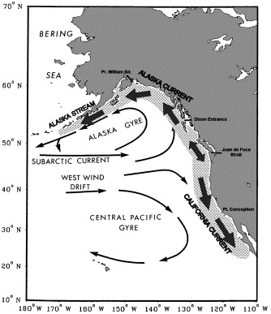

1. [Download: Download full-size image](https://ars-els-cdn-com.reed.idm.oclc.org/content/image/1-s2.0-S0967064505000056-gr1.jpg)

Fig. 1. Map of the NE Pacific (adapted from Ware and McFarlane, 1989) showing location of the shelf–slope–offshore transition region (shaded area) and annual-averaged large-scale current patterns (arrows). The coastal transition region includes both the NE Pacific alongshore boundary current systems: the equatorward/upwelling California Current and the poleward/downwelling Alaska Current/Alaska Coastal Current. Although not shown in the annual averages, the boundary currents undergo seasonal variability in speed and direction (generally more poleward/less equatorward in winter, more equatorward/less poleward in summer), and both produce strong mesoscale cross-shore motion in the form of meanders, eddies, and filaments.

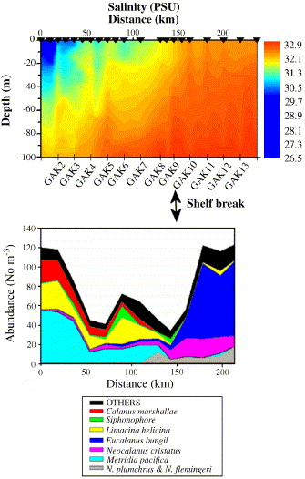

1. [Download: Download full-size image](https://ars-els-cdn-com.reed.idm.oclc.org/content/image/1-s2.0-S0967064505000056-gr2.jpg)

Fig. 2. Cross-shore change in zooplankton community composition off Alaska. Note the strong gradient at the shelf break. From Coyle and Pinchuk (in press).

As noted by Longhurst (1998), the transition region between shelf and deep ocean is an ecotone with some special characteristics that differ from the environments and communities on either side. Barriers to cross-shore exchange of water and organisms across this transition are both leaky and variable in their location and effectiveness. The zooplankton community patterns we observe result from the interaction of physical transport processes with zooplankton life history and behavior. Many of these processes vary in sign and intensity with latitude and also in time (wind events, seasonal cycle, and interannual). Because zooplankton life cycles and depth distributions are also strongly seasonal, there are important interactions that could potentially drive large match–mismatch variations in distribution and survivorship of both zooplankton and their predators.

Although both the southern (California Current) and northern (Alaska Current) portions of the transition region are physically energetic and biologically productive (Longhurst, 1998), the dominant modes of physical forcing and nutrient enrichment differ strongly (Hickey, 1998; Royer, 1998). The northern shelf is dominated by onshore downwelling winds most of the year. In addition, the proximity of the Aleutian low atmospheric pressure cell plus mountainous coastal topography results in large amounts of precipitation along the Alaskan coast. This precipitation and runoff drives an intense coastal current (Alaskan Coastal Current, ACC), which is the dominant physical oceanographic feature on the shelf between the southeastern Alaskan archipelago and Samalga Pass in the eastern Aleutian Islands (Royer, 1998; Coyle, in press). Waters in the ACC and adjacent fjords are often highly stratified by both salinity and temperature, especially in summer and fall when runoff and precipitation are maximum. This stratification leads to nutrient depletion in the upper water column following the spring bloom, and subsequent blooms are limited to periodic wind events, which temporarily break up the stratification and inject nutrients into the euphotic zone.

In contrast, the coast from southern British Columbia south to California is dominated by seasonal wind-driven upwelling. Nutrients are pumped onshore and upwelled along the coast, resulting in elevated primary production during much of the spring and summer. A persistent buoyancy-driven coastal current is absent south of Vancouver Island, and coastal waters are usually characterized by relatively low temperatures (compared to offshore locations) and high salinities associated with the upwelling.

In this paper, we review mechanisms and consequences of cross-shore exchange of zooplankton in the NE Pacific. We will begin with a comparison and contrast of the characteristics of nearshore vs. oceanic environments, and of nearshore vs. oceanic zooplankton taxa. We will next review important physical exchange processes, their latitudinal and seasonal variability, and how they affect NE Pacific zooplankton communities. The physical processes include:

- •

  coastal upwelling/downwelling,
- •

  estuarine circulation driven by coastal freshwater runoff,
- •

  interaction of currents with submarine canyons,
- •

  filaments and meanders produced by instability of equatorward and poleward boundary currents,
- •

  westward propagation of “large” coastal-origin geostrophic eddies due to latitudinal gradient in Coriolis force.

We also will describe the biological adaptations that affect the probability of zooplankton survival and retention in nearshore or offshore environments. These include:

- •

  diel and ontogenetic vertical migration of zooplankton across shears of the horizontal currents,
- •

  life-cycle timing, seasonal dormancy, and reproductive strategy.

Finally, we will conclude with a list of as-yet unanswered questions: distributional puzzles and uncertainties about processes that deserve further research.

## 2. Nearshore vs. offshore: environmental conditions and zooplankton adaptations

Both nearshore and offshore environments are variable in time. In particular, both undergo strong seasonal cycles, especially at mid-to-high latitudes. However, nearshore (continental shelf) and offshore (deep ocean) environments differ in a number of important ways (Table 1). The continental shelf water column is of course much smaller in vertical extent. Around most of the NE Pacific the continental shelf is also relatively narrow, and horizontal gradients in environmental conditions are much steeper than in the open ocean. Horizontal currents in the nearshore zone, especially at and near the shelf break, are also often fast (order 10–100 cm s<sup>−1</sup>). One important consequence of the differences in spatial extent and flow patterns is that typical sustained current speeds can move nearshore zooplankton between very different environmental conditions within the span of a single generation, or even a single life stage. Minimizing alongshore and cross-shore transport to stay in a favorable but localized environment can be a difficult but important ecological challenge for nearshore zooplankton (Peterson, 1998). Conversely, the coastal ocean can be an easier environment for zooplankton to obtain food, and in some cases to avoid becoming food. Rates of nutrient supply and primary productivity, and average phytoplankton biomass (especially of larger cells) are all usually higher, and often more sustained in nearshore than in offshore regions (see, e.g., Whitney et al., 2005). Spatially predictable hydrodynamic structures that produce/aggregate patches of even higher food availability (e.g., fronts, upwelling centers, tidal convergences and divergences) are also common in continental shelf settings. Less transparent water and lower subsurface light levels caused by phytoplankton blooms and/or coastal-origin sediments and dissolved organic matter provide some daytime concealment from near-surface visual predators.

Table 1. Comparison of nearshore and deep ocean regions as zooplankton environments

| Environment | Nearshore—continental shelf | Offshore—deep ocean |
| --- | --- | --- |
| Spatial extent |  | Very “large” area |
| Vertical structure | Shallow water column, upper ocean interacts physically and biologically with seabed | Deep water column, upper ocean interacts biologically with mesopelagic (via sinking and vertical migration) |
| Density stratification | Stratification continuous to sea surface (wind-mixed layer shallow or absent) | Deep wind-mixed layer underlain by a strong pycnocline |
|  | *or* |  |
|  | Entire water column mixed by tidal currents |  |
| Primary productivity and phytoplankton community structure | High annual primary productivity, episodic blooms of large phytoplankton cells | Phytoplankton dominated by small cells, often nutrient limited, fewer and weaker blooms |
| Horizontal currents |  |  |
| Persistent | Strong alongshore geostrophic currents across latitudinal gradients | Slow mean currents, recirculating around major gyres |
| Time-varying | Dominated by tides, wind events, and meandering of boundary currents (across strong cross-shore gradients) | Dominated by geostrophic eddies, wind events, and inertial oscillations |

Because of the differences in environmental conditions, the mesozooplankton species endemic to continental shelf and offshore regions also differ in their morphological and life-history adaptations (Table 2). Some of the trends and tendencies listed in Table 2 are evident at all NE Pacific latitudes from subtropical to subarctic. For the crustacean zooplankton, characteristics of the nearshore and shelf community include a greater prevalence of phytoplankton in the overall diet and of benthic (sometimes dormant) eggs. Offshore there is a greater prevalence of carnivory/omnivory as a feeding mode (both within a given species, and as gradients in which species are dominant), greater prevalence and range of diel and seasonal vertical migration, and of mesopelagic pre-adult dormancy. Meroplanktonic larvae of shallow-water benthos and demersal fish are abundant over the NE Pacific continental margin, especially in spring and early summer. Ctenophores and cnidarians (hydromedusae, scyphomedusae, siphonophores) are often dominant zooplankton predators on the continental shelf, especially in “green-water” conditions (Suchman and Brodeur, 2003; Larsen, 1987). Seaward of the continental shelf break, migratory micro-nekton and chaetognaths become more important (although some chaetognaths, e.g., *Parasagitta elegans* and *P. euneritica*, are also abundant on the NE Pacific continental shelf).

Table 2. Comparison of life history, morphological, and trophic characteristics of nearshore (continental shelf) vs. deep ocean copepods in the NE Pacific

| Environment | Nearshore–continental shelf | Offshore—deep ocean |
| --- | --- | --- |
| Life span/life history | 1–4 generations year<sup>−1</sup> | 1–2 generations year<sup>−1</sup> |
|  | Multiple cohorts often present. Episodic reproduction and development phased with upwelling events | At higher latitudes reproduction and development are strongly seasonal (∼spring) |
|  | Often dormant eggs, on or in sediments | Dormancy as pre-adult, tied to deep ontogenetic migration |
| Individual body size |  |  |
| ∼45–60°N | Smaller than offshore, similar to further south | Large |
| ∼30–45°N | Similar to offshore and further north | Similar to nearshore |
| Taxonomic richness |  |  |
| ∼45–60°N | Slightly less diverse | Slightly more diverse |
| ∼30–45°N | Less diverse | More diverse |
| Feeding type | Omnivorous, but obtaining much of their ration from phytoplankton | Mix of omnivores and carnivores, with omnivores obtaining much of their ration from micro-zooplankton |
| Major predators | Cnidarians, ctenophores, chaetognaths, juvenile and adult epipelagic fishes | Chaetognaths, crustacean zooplankton, migratory micro-nekton |
| Vertical migration |  |  |
| Diel | Less consistent and narrower vertical range, may aid spatial retention | Very common, probably mostly for predator avoidance |
| Ontogenetic | Facultative, may aid spatial retention | Obligate and deep when present, aids seasonal survival |

Other differences between shelf and offshore regions are most evident within particular portions of the latitude range and seasonal cycle. For example, the tendencies in the offshore region toward larger body-size (Fig. 3), annual generation length, and obligate seasonal dormancy are more clear in the subarctic Pacific and especially so for the taxa that are dominant in the spring–early summer season. The tendencies toward higher offshore taxonomic diversity and more stable dominance hierarchy (both within and between taxonomic categories) are most evident below about 40–45°N latitude (California Current vs. Central Gyre; McGowan and Walker, 1985).

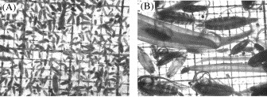

1. [Download: Download full-size image](https://ars-els-cdn-com.reed.idm.oclc.org/content/image/1-s2.0-S0967064505000056-gr3.jpg)

Fig. 3. Size-composition contrast between spring season shelf and offshore zooplankton communities in the subarctic NE Pacific. Background grid is 1 mm in both photos. (A) Sample from the Vancouver Island continental shelf (48.6°N 125.75°W, bottom depth=65 m). (B) Sample from Station P in the Alaska Gyre (50°N 145°W, bottom depth=4200 m, tow depth=150 m).

Zooplankton distributions and adaptations are very strongly conditioned by the cross-shore and latitudinal differences in currents. Some of the cross-shore zonation of zooplankton characteristics is a consequence of the prevailing directions of the alongshore boundary currents: poleward at higher latitudes (Royer, 1998), equatorward at lower latitudes (Hickey, 1998) (Fig. 1). Transport by these strong alongshore currents tends to broaden and weaken the latitudinal gradient between subarctic and subtropical faunas: at high latitudes, shelf and slope currents carry a more southerly fauna poleward for much of the year, while at lower latitudes the California Current carries a more northerly fauna equatorward.

## 3. Physical processes causing shelf–offshore exchange, and their effects on zooplankton

### 3.1. Basin-scale circulation

Between about 35°N and 48°N latitude, the large-scale zonal circulation of the North Pacific is from west to east (Fig. 1). The North American continental margin is at the receiving end of this flow. However, maps of water properties and dynamic topography (e.g., Strub and James, 2002) show that the trans-Pacific flow bifurcates a long-distance offshore and is much slower and less seasonal than the boundary currents. Quantitative importance of the basin-scale convergence is not fully established, but it appears likely that little mid-Pacific water reaches the coast between California and southeast Alaska without extensive prior modification and dilution. The importance of onshore convergence of oceanic water may be greater along the northern margin of the basin (see below), but this is primarily due to strong onshore Ekman transport (Section 3.2) and to closer proximity to shore of strong alongshore currents, rather than a persistent onshore geostrophic flow.

### 3.2. Wind-driven Ekman transport

If winds are steady for more than about a day or two (depending on latitude), surface wind stress, Coriolis force, and vertical shear/friction within the water column interact to produce a horizontal motion of the upper layer (Ekman transport) that is at right angle to the prevailing wind direction (see e.g. Gill, 1982 or Bakun, 1996 for more complete discussion). Winds near the coast frequently have a large alongshore component. This leads to strong near-surface cross-shore transport within the coastal transition zone (seaward if the coast is to the left of the wind vector, shoreward if the coast is to the right of the wind vector), and also to horizontal divergence/upwelling or convergence/downwelling near the coast, and also in regions of horizontal shear (curl) of the wind stress. Convergence/divergence of the surface layer is compensated by a slower divergence/convergence of water in the deeper remainder of the water column. Often (but not always), the compensating motion is in the opposite direction to the surface Ekman transport.

The intensity and direction of the wind-driven Ekman transport are strongly and systematically variable with both season and latitude (Fig. 4 from Schwing et al., 1996). Coastal divergence and upwelling are the norm in the California Current system, and are seasonally most intense in spring and summer, and between about 30°N and 42°N latitude (central California to southern Oregon). Coastal convergence and downwelling are the norm in the Alaska Current system and are seasonally most intense in autumn and winter, and north of about 52°N (northern British Columbia and Alaska). Throughout much of the NE Pacific latitudinal range, there are seasonal reversals in the monthly average directions of wind and Ekman transport (called the spring and fall transitions). The patterns shown in Fig. 4 are multi-year averages, and the time sequence in any given year is less smooth. Onsets of the spring and fall transitions are often much more abrupt, but are variable in timing from year to year, and also with latitude (Strub et al., 1987; Thomson and Ware, 1996). Individual weather events also can produce episodes of seaward or shoreward Ekman transport at any location and in any season. Cross-shore transport speeds within the Ekman layer are fastest where and when alongshore winds are strongest (the upwelling/downwelling maxima in Fig. 4). Seasonal average cross-shore velocities of a few kilometers per day are relatively common, but are faster during strong wind events, and near topographically localized upwelling centers. At the end of a strong upwelling wind event, there is also often a rapid reversal of the previous seaward surface water motion—a phenomenon called “relaxation” that restores the cross-shore density field to something close to its seasonal average (see Bakun, 1996, for a basic discussion of speed and mechanism). Both in the north and in the south, cross-shore Ekman transport adds macro-nutrients into the coastal zone—in the south through upwelling of nutrient-rich deep water, and in the north through shoreward transport of high-nitrate (but low-iron) water from the high-nutrient, low-chlorophyll (HNLC) waters of the Alaska Gyre (Weingartner et al., 2002; Whitney et al., 2005). Alongshore winds and Ekman transport also contribute to the development of strong cross-shore gradients in water properties and sea-level height—seaward transport by moving low-density surface water offshore and replacing it with upwelled denser (saltier and colder) water, shoreward transport by retaining and accumulating low-salinity surface water near the coast. The resulting strong cross-shore density and pressure gradients in turn maintain and increase the speed of the geostrophic boundary currents, and contribute to the growth of cross-shore instabilities of these currents (discussed in Section 3.5).

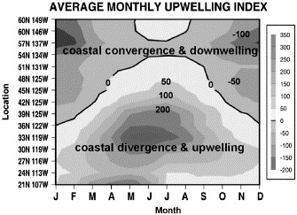

1. [Download: Download full-size image](https://ars-els-cdn-com.reed.idm.oclc.org/content/image/1-s2.0-S0967064505000056-gr4.jpg)

Fig. 4. Seasonal and latitudinal variability in strength and direction of cross-shore Ekman transport (from Schwing et al., 1996).

The vertical extent of the Ekman layer is rarely deeper than 75 m, and often shallower (∼25–50 m) due to stratification and reduced eddy viscosity at the base of the mixed layer. The zooplankton most affected by Ekman transport are therefore those residing within the surface mixed layer (although zooplankton deeper in the water column are exposed to the slower compensating deep flows). Herbivorous zooplankton must enter the near-surface layer to feed, and many of the dominant NE Pacific copepod species spend their early life stages almost entirely within the upper 50 m. Conversely, older life stages of many zooplankton species vertically migrate below the Ekman layer, either daily, or as part of their normal growth and development sequence. The result is strong seasonal, latitudinal, and ontogenetic variability of cross-shore zooplankton transport. Several studies have examined the occurrence and importance of cross-shore transport at various locations along the NE Pacific margin.

Off Alaska and northern British Columbia, the general pattern is (as expected from Fig. 4) a predominance of shoreward and poleward/westward alongshore transport through all or most of the year. Cooney (1988, Fig. 5) noted that the Alaskan continental margin receives a very large annual advective input of large oceanic copepods (primarily *Neocalanus plumchrus/flemingeri* and *N. cristatus*). Zooplankton biomass on the shelf is dominated by these oceanic species that are advected shoreward during spring, whereas abundance is dominated by smaller taxa (*Pseudocalanus* spp., *Oithona similis*) (Coyle and Pinchuk, 2003; Incze et al., 1996; Cooney, 1986, Cooney, 1988). Neritic species are particularly prominent in the ACC, where zooplankton abundance is often consistently higher than in adjacent shelf waters (Napp et al., 1996; Coyle and Pinchuk, in press). In nearshore basins where the bottom is deep enough to accommodate their ontogenetic migration (for example, Prince William Sound, the Strait of Georgia, and in many smaller inlets and fjords), the oceanic species can establish year-round populations that are an important food source for coastal populations of juvenile salmon and herring (Cooney et al., 2001). In these instances, it is useful to know how much of the total biomass came from offshore, and how much grew within the local coastal basin. Kline (1998) examined this question using the stable isotope ratios of carbon and nitrogen measured in bulk zooplankton, in juvenile fish, and in individual copepods. He found (Fig. 6) that *Neocalanus* in Prince William Sound have two modes of isotopic composition—copepods with isotopically light carbon content (the groups indicated by solid-line ellipses in Fig. 6) that acquired most of their body mass in the offshore region, and isotopically heavy copepods (indicated by dashed-line ellipses) that fed and grew within the nearshore zone. The fraction of the population in the nearshore vs. offshore modes differs seasonally and also between years.

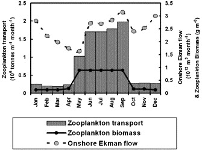

1. [Download: Download full-size image](https://ars-els-cdn-com.reed.idm.oclc.org/content/image/1-s2.0-S0967064505000056-gr5.jpg)

Fig. 5. Estimation of onshore Ekman transport of oceanic-origin zooplankton biomass onto the Alaska continental shelf: seasonal time series of offshore biomass of large oceanic copepods (mostly *Neocalanus* spp.), cross-shore Ekman velocity estimated from winds, and the calculated onshore flux of copepod biomass (graphed from transport and biomass estimates tabulated in Cooney, 1988).

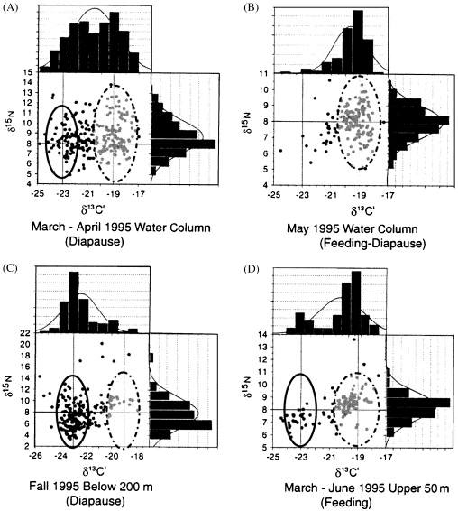

1. [Download: Download full-size image](https://ars-els-cdn-com.reed.idm.oclc.org/content/image/1-s2.0-S0967064505000056-gr6.jpg)

Fig. 6. Isotopic characterization of *N. cristatus* in a large, deep Alaskan coastal fjord system (Prince William Sound). Carbon in copepods that fed and grew offshore is isotopically lighter (solid-line ellipse) than in copepods that fed and grew nearshore (dashed-line ellipse). Both types are present in Prince William. The percentage of each type varies seasonally, and also from year to year. Adapted from Kline (1998).

At latitudes below about 50°N (southern British Columbia to California), surface Ekman transport of zooplankton is on average seaward. The seaward transport is especially strong after the spring transition, during the summer upwelling season when food supply and zooplankton reproduction and growth rates are often high. Studies of zooplankton spatial distribution and seasonal cycle off Vancouver Island (Fig. 7, Mackas, 1992; Mackas and Yelland, 1999) have shown that the summer rate of seaward advective export of zooplankton can be substantial (several percent per day, comparable to local rates of predation mortality) and is an important loss term for shelf populations and a source term for populations in the continental slope and offshore regions. Studies off Oregon (Morgan et al., 2003; Peterson et al., 2002; Keister and Peterson, 2003) reached similar conclusions, but with the important added interpretation that for some zooplankton taxa (e.g., *Clausocalanus* spp.) the outer continental slope region provides a seasonally important habitat and temporary refuge from alongshore advection, allowing them to be returned to the continental shelf once strong upwelling ceases. Coastal upwelling zones are usually rich in food for herbivorous zooplankton and are therefore a good place to grow and produce eggs. But because of their small areal extent and rapid advective throughput, they can be difficult places to stay for small animals with limited swimming ability. Nearshore retention or return is a difficult but important ecological requirement for upwelling zone residents. As noted above, juvenile life stages are often distributed near the sea surface and are particularly exposed to cross-shore Ekman transport. In a classic study, Peterson et al. (1979) (Fig. 8) showed that zooplankton living in upwelling regions have vertical distribution patterns that exploit vertical shear of the cross-shore transport direction, and help these species to achieve life-cycle closure within the upwelling habitat. Because Ekman transport varies seasonally in both speed and direction, there is an important potential interaction between the timing of life-history events (seasonal vertical migration, reproduction, and development) and the timing of changes in winds and currents. Many zooplankton life-cycle events occur in spring (probably to take advantage of the seasonal increase in food availability) at about the same time wind and current patterns are undergoing rapid seasonal transitions. Exact timings of both the zooplankton and the physical variability vary from year to year. We do not yet fully know the consequences of the resulting timing interactions. For example, Lu et al. (2003) showed that euphausiid larvae are transported shoreward from their parent population before the spring transition, but seaward after the spring transition. Are both transport patterns “optimal” for their respective conditions, or is one situation an adaptive fitness “match” and the other a “mismatch”? We will discuss this evolutionary question more in the final section.

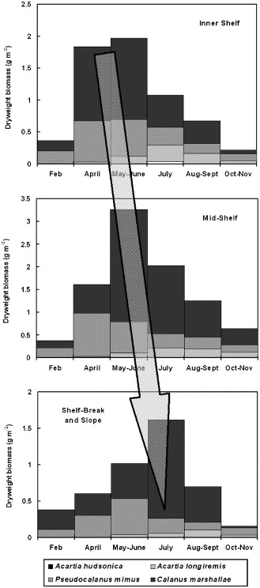

1. [Download: Download full-size image](https://ars-els-cdn-com.reed.idm.oclc.org/content/image/1-s2.0-S0967064505000056-gr7.jpg)

Fig. 7. Evidence for seaward Ekman transport of zooplankton biomass from the Vancouver Island continental shelf: seasonal cycles of biomass for four copepod species endemic to the Vancouver Island continental shelf in inner shelf, mid-shelf, and offshore regions. Peak biomass occurs in May on the inner shelf, and declines later in the summer, despite continued high food availability. Seaward of the shelf break, peak biomass of the shelf-origin species occurs 2 months later (despite lower food availability than on the inner shelf). This is best explained by cross-shore export (arrow) from the inner shelf to the continental slope. Adapted from Mackas (1992).

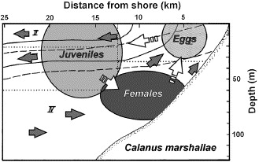

1. [Download: Download full-size image](https://ars-els-cdn-com.reed.idm.oclc.org/content/image/1-s2.0-S0967064505000056-gr8.jpg)

Fig. 8. Ontogenetic changes in copepod vertical distribution enhance retention in the Oregon coastal upwelling zone. Ellipses show centers of distribution for different life stages. Dark arrows show the cross-shore component of upwelling circulation. White arrows show the more restricted trajectory of the copepods. Composited and simplified from figures in Peterson et al. (1979).

### 3.3. Estuarine circulation/coastal runoff

A large amount of land-derived freshwater runoff crosses the NE Pacific coastal boundary from the Columbia River north (i.e., north of about 45°N). Runoff is strongly seasonal (Royer, 1998; Weingartner et al., in press), peaking in summer off Washington and parts of British Columbia (due to snowmelt inputs to a few large river systems such as the Columbia, Fraser, and Skeena) but with an overall maximum in autumn. This freshwater spreads seaward over, and entrains (through tidal and wind mixing) underlying ocean water, setting up a positive estuarine circulation with seaward surface flow and shoreward deep flow. Resulting cross-shore velocities are usually much smaller than the Ekman transports described in the previous section, but are as large or larger (>10 km day<sup>−1</sup>) within estuaries and in large straits such as Juan de Fuca and Dixon Entrance. Because the depth range influenced by the estuarine circulation in these straits extends deeper than the nutricline, the estuarine conveyor belt can be a locally dominant mechanism for nutrient input (Whitney et al., 2005; Mackas and Harrison, 1997; Crawford and Dewey, 1989). This has an important indirect influence on the zooplankton population via bottom-up enrichment of primary productivity. Perhaps more broadly important, coastal freshwater inputs also have a large influence on the alongshore circulation, driving rapid and sometimes unstable coastal buoyancy currents in the northern coastal region (the Alaska and Vancouver Island Coastal Currents, Stabeno et al., in press; Royer, 1998; Thomson et al., 1989), with effects discussed in Section 3.5.

### 3.4. Submarine canyons

Beneath the strong boundary currents that follow the NE Pacific shelf break and upper continental slope, the seabed is cut by a large number of steep-sided and relatively narrow submarine canyons. These have a substantial influence on local direction of the boundary currents, on water properties, and on distributions of zooplankton and their predators (Allen et al., 2001; Mackas et al., 1997; Schoenherr, 1988). Unlike the other physical processes discussed in this paper, the major impact is on zooplankton living deeper in the water column (between the rims of the canyon), and the key mechanism appears to be spatial aggregation/convergence due to interaction between within-canyon flow fields and vertical positioning behavior of the zooplankton (Genin, 2004).

### 3.5. Boundary current instabilities

One of the important achievements of “satellite oceanography” has been the very clear and detailed evidence satellite images provide on the intense mesoscale cross-shore flows (meanders, eddies, cross-shore filaments, and jets) embedded within the NE Pacific boundary current systems (Fig. 9, Fig. 10). The oceanographic causes and effects of these mesoscale features have been the subject of considerable (and still ongoing) study since the early 1980s in the California Current (Brink and Cowles, 1991; Strub et al., 1991; Hickey, 1998), and more recently in the Alaska Current/Alaska Coastal Current/Alaska Stream (Okkonen et al., 2003; Royer, 1998; Stabeno et al., in press; Ladd et al., in press). In both the equatorward and the poleward current systems, cross-shore motions arise from instability of the alongshore currents. These are often initially triggered where and when strong alongshore currents encounter irregularities in the coastline and/or bottom topography.

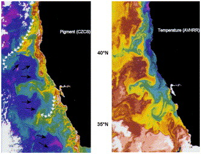

1. [Download: Download full-size image](https://ars-els-cdn-com.reed.idm.oclc.org/content/image/1-s2.0-S0967064505000056-gr9.jpg)

Fig. 9. Satellite images of California Current cold-core filaments showing the similar patterns of phytoplankton biomass and cold upwelled water. Left panel is phytoplankton pigment (high chlorophyll indicated by red and yellow colors), right panel is sea-surface temperature (low temperature=purple and blue colors). Seaward flow is most rapid within a narrow band along the northwest frontal margin of the filaments (indicated by white arrows on two of the filaments). Slower and more diffuse shoreward flow occurs south of each filament (indicated schematically by black arrows). Figure adapted from Brink and Cowles (1991).

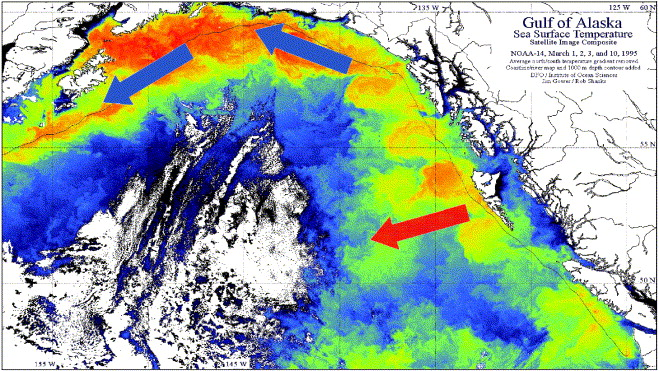

1. [Download: Download full-size image](https://ars-els-cdn-com.reed.idm.oclc.org/content/image/1-s2.0-S0967064505000056-gr10.jpg)

Fig. 10. Satellite image showing large anticyclonic eddies that form in late winter–early spring along the eastern margin of the Alaska Gyre. Color code indicates temperature anomaly (latitudinal trend removed). Each eddy contains a core of coastal-origin water (fresher and initially warmer than the offshore surface water). During the 1–3 years after their formation, the eddies propagate long distances westward, either seaward into the Alaska Gyre (red arrow) or along the northern margin of the basin (blue arrows). Adapted from Thomson and Gower (1998).

However, the difference in the direction of the alongshore current (equatorward with coastline and continental shelf boundary on the left for the California Current vs. poleward with coast and shallower bottom on the right for the Alaska Currents) causes seaward meanders to be cyclonic and with upward-domed isopycnals in the California Current vs. anticyclonic and with downward-displacement of isopycnals off northern British Columbia and Alaska. There are also north vs. south differences in the size and shape of the features.

#### 3.5.1. California Current filaments and meanders

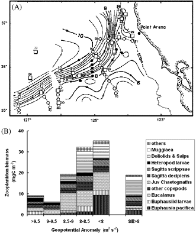

1. [Download: Download full-size image](https://ars-els-cdn-com.reed.idm.oclc.org/content/image/1-s2.0-S0967064505000056-gr11.gif)

Fig. 11. Seaward zooplankton transport by California Current filaments, from Mackas et al. (1991). (A) Map of zooplankton sampling locations, superimposed on contours of geopotential anomaly. Fastest flow (closely spaced contours) is in a frontal region north of the cold core of the filament. (B) Zooplankton biomass and community composition plotted vs. geopotential anomaly. Although highest biomass is within the slowly moving core of the filament (smallest geopotential anomaly), relatively high biomass extends into the zone of rapid seaward flow (geopotential anomaly=8–9).

#### 3.5.2. Seaward propagating anticyclonic eddies around and in the Alaska Gyre

In more northerly regions, meanders of the alongshore Alaska Current pinch off and form large, fresh-core, anticyclonic eddies (Fig. 10). Eddy formation within the nearshore region is most active in late winter and early spring as poleward winds weaken, and occurs at preferred locations along the coast (Crawford, 2002; Whitney et al., 2005). Once the eddies have formed, they propagate westward at average speeds of ∼1–2 km day<sup>−1</sup>. As they move seaward, eddies are colonized by continental margin (shelf, slope) and oceanic (Alaska Gyre) zooplankton species. Depending on their starting location, their westward propagation takes them either into the interior of the Alaska Gyre (for eddies originating south of about 55°N), or along the north margin of the basin (for eddies that form further north). Eddies contribute to cross-shore exchange by at least two mechanisms—the slow seaward propagation (and leakage) of the eddy core, and the more rapid motion and entrainment that occurs around the eddy margin. Eddy-mediated seaward transport of coastal water and onshore movement of oceanic water is especially evident when eddies are centered over the continental slope along the southern Alaska coast (Crawford et al., in press; Okkonen et al., 2003). Eddies contain elevated levels of coastal-origin nutrients (iron and silicate), and enhance primary productivity, and the likelihood of phytoplankton bloom formation and nitrate depletion, in the eastern part of the HNLC Alaska Gyre (Whitney et al., 2005; Johnson et al., in press). This provides bottom-up food web enrichment for offshore zooplankton that colonize the eddies (probably the largest impact on the offshore region). Shelf and slope-origin zooplankton are also carried several hundreds of kilometers into the Alaska Gyre by the eddies, and maintain anomalously high abundance for several months (Mackas and Galbraith, 2002; Batten and Crawford, in press, Fig. 12). However, eddies are very ‘leaky’. The taxa (both coastal and oceanic) most able to persist within the eddies are those that avoid the surface Ekman layer and its strong wind-driven currents. Even these are dispersed fairly rapidly into the surrounding offshore water (Fig. 12). It is likely that the offshore ecological impact of the coastal-origin zooplankton is relatively localized (the fraction of the Alaska Gyre actually occupied by coastal-origin eddies is only 1–2%, Crawford, 2002). Removal of the same volume/area of coastal water and biomass/number of organisms may have a much larger impact on the more spatially restricted nearshore environment. The effect on zooplankton communities of the more northerly eddies that remain close to the Alaskan boundary is now being studied, but initial results (e.g., Coyle and Pinchuk, in press) are showing that eddies propagating westward along the Alaskan coast also contribute to cross-shore exchange (offshore origin taxa carried toward the coast at the leading edge of the clockwise-rotating eddy; shelf-origin taxa carried seaward at the trailing edge of the eddy).

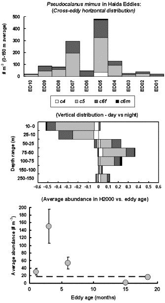

1. [Download: Download full-size image](https://ars-els-cdn-com.reed.idm.oclc.org/content/image/1-s2.0-S0967064505000056-gr12.jpg)

Fig. 12. Distribution of the continental shelf copepod *P. mimus* in an offshore Haida Eddy (H2000), from Mackas and Galbraith (2002). (Top) Horizontal distribution along a south-to-north section across the eddy. Highest abundance is near the eddy center. Middle: vertical distribution in the upper 250 (left side=night, right side=day). (Bottom) Change in abundance with increasing eddy age.

## 4. Zooplankton adaptations: behavioral and life-cycle interactions with ocean currents

### 4.1. What we know

Typical zooplankton swimming speeds (one to a few cm s<sup>−1</sup>) are slower than typical horizontal velocities of currents in the coastal ocean. Zooplankton also in general lack the sensory capability to detect the speed and direction of any large-scale horizontal motion in which they are embedded. How then do they get to, and maintain themselves in, optimal habitat locations? One answer is that many individuals probably do *not* succeed at staying in optimal habitat—they are carried away by ocean currents to locations that are less suitable for growth, survival, or reproduction. In some highly productive continental margin environments, high growth and reproduction rates of the nearshore species may be sufficient to offset this loss (Escribano, 1998). However, a recurrent theme in the preceding sections has been that zooplankton spatial and temporal distributions (especially vertical distributions, and timing with respect to seasonal and event-scale changes in wind and currents) strongly affect their rate and direction of advective transport. Avoidance of the surface layer usually reduces transport speed and favors local retention. “Upper-ocean” mesozooplankton exhibit a wide range of depth preferences and vertical positioning behaviors (see, e.g., Paffenho˝fer and Mazzocchi, 2003; Lamb and Peterson, in press), and there is increasing evidence that preferred depths vary as a function of upper-ocean stratification and wind mixing (e.g., Mackas et al., 1993; Lagadeuc et al., 1997; Incze et al., 2001; Visser et al., 2001), and also very strongly as a function of life stage within species (Peterson et al., 1979; Lamb and Peterson, in press; Lu et al., 2003). Wind-driven currents have strong vertical shear across a narrow range of depths, especially near the base of the surface mixed layer. It is therefore easy for zooplankton to swim vertically between very different transport regimes. This concept is far from new (Hardy, 1958), but remains central to many questions about zooplankton evolution and spatial distribution. Both field observations (Peterson et al., 1979; Verheye et al., 1991; Barange and Pillar, 1992) and numerical simulation models (Batchelder et al., 2002; Wroblewski, 1982) provide strong evidence that continental margin zooplankton exhibit vertical positioning behavior that enhances their probability of spatial retention and life-cycle closure.

At present, it is somewhat less clear how this positioning behavior is turned on and off. Zooplankton do know “which way is up”, due to strong vertical gradients of light and water properties, and the ability to sense movement resulting from buoyancy contrast with the surrounding water. They also are able to detect strong micro-scale (∼1 cm or smaller) turbulent shear (Kiorboe et al., 1999; Fields and Yen, 1997). However, although the intensity of micro-scale turbulence in the upper water column is broadly correlated with surface wind stress and with the strength of larger-scale shear across the pycnocline and at the seabed, turbulence at the sensory scale of the individual organism retains little directional information about these larger scales. Behavioral response to turbulence becomes important for vertical positioning if the zooplankton exhibit a consistent and strongly directional behavioral response (e.g., swimming up or down) to the strength of micro-scale turbulent shear, independent of the orientation of the shear vector.

Latitudinal gradients in day length during the growing season also may have important effects on the migration/advection interaction. At high latitudes in summer, the residence time of diel vertical migrators in the upper mixed layer is short and residence time below the pycnocline is long. In the California Current system, the diurnal light-cycle is more balanced and results in a more equal partitioning of time between the surface and deep layers. In either region, strong evolutionary selection is possible for behavior (short-term stimulus-response patterns) and life history (longer-term ontogenetic changes in distribution) that put individual zooplankton in the right part of the water column at the right time. The problem is that evolutionary adaptations reflect what has happened persistently and repeatedly in the past. The advective environment of the coastal transition zone is neither spatially homogeneous nor very predictable over time—there are large variations around regional average conditions due to interactions of flow patterns with local bathymetry, to individual weather events within a year, and to shifts in seasonal phasing from year to year. As well, individual species are often quite successful in very different environments, and despite large spatial differences in advective climatology. For example, Ressler et al. (in press) have shown that off Oregon, adult euphausiids aggregate/accumulate most strongly in two very different locations: near Heceta Bank (a shelf edge bank with a topographically steered gyre that enhances recirculation/retention) and off Cape Blanco (a zone of strong seaward transport caused by a large and persistent offshore filament). Peterson and Keister (2002) show that while one “shelf” species (*Pseudocalanus mimus*) is transported off the Oregon shelf by the Cape Blanco filament and becomes relatively abundant in outer continental slope and offshore waters, another (*Calanus marshallae*) is rarely found much beyond the shelf break. This between-species contrast recurs off northern British Columbia, where seaward propagating coastal-origin anticyclonic eddies contain relatively large numbers of *P. mimus* (Fig. 12) but few *C. marshallae* (Mackas and Galbraith, 2002). Off southern British Columbia, several additional species that occasionally reach very high abundance show pronounced cross-shore abundance maxima centered over the continental slope (e.g., the planktonic tunicates *Salpa fusiformis*, *S. aspera*, and *Dolioletta geigenbaurii*, the pteropods *Limacina helicina* and *Clio pyramidata*, plus more consistently adults and late juvenile stages of the euphausiid *Euphausia pacifica*).

In high latitude regions of the North Atlantic (∼40–70°N), *Calanus finmarchicus* is the dominant large copepod in both shelf and oceanic regions. On both east and west sides of the Atlantic, most continental shelf populations of *C. finmarchicus* are now believed to derive largely from annual colonization from the adjoining deep ocean, via a large advective/migratory input along and across the shelf break and upper continental slope (papers in Heath and Coombs, 1999; Head et al., 1999). This pattern of dominance by a single species in both shelf and offshore regions is less evident at comparable latitudes in the NE Pacific (northern California Current, Alaska Current/Alaska Coastal Current, and Bering Sea). *Neocalanus* spp. strongly dominate the copepod biomass in offshore regions seaward of the shelf break. *Neocalanus* also dominate the copepod biomass on the Gulf of Alaska (GOA) shelf during spring, but largely disappear by early summer (Coyle and Pinchuk, 2003). In the northern California Current and Bering Sea, and for the remainder of the growing season on the Alaskan GOA shelf, *C. marshallae* is often the dominant species on the shelf, but declines rapidly in abundance seaward of the shelf break. South of about 40°N in the California Current system, *Calanus pacificus* takes over from *C. marshallae* as the dominant large copepod both offshore and along the continental margin (Rebstock, 2001). The cross-shore abundance maximum during the growing season is within the boundary current system, but there is increasing evidence that *C. pacificus* uses winter dormancy in deep offshore regions (specifically the poleward California Undercurrent) as a recirculation and retention mechanism (Johnson and Checkley, in press).

Continental margin holozooplankton must achieve retention and life-cycle closure over the time scale of a full generation (i.e., several weeks to a year). For meroplanktonic species, the critical time window to achieve retention or return is very much shorter (e.g., for many benthic invertebrates, a few days duration of settlement competency within a single life stage). In upwelling regions and seasons where the average surface Ekman transport is seaward, shoreward transport mechanisms are especially important as controls on recruitment rate and location. This issue has received intensive study in the California Current region. One key shoreward return mechanism involves behavioral aggregation at the upwelling front, and rapid shoreward displacement of this front during episodes of weakened alongshore wind stress (Roughgarden et al., 1988). Another is seasonal phasing of reproductive activity before the strongest upwelling (Connolly et al., 2001). A third is utilization of shoreward-propagating internal wave trains as both aggregation foci and transport mechanisms (Pineda, 1999; Shanks, 1983).

### 4.2. What we do not yet know: mysteries and questions for the future

Many questions remain to be answered. In our opinion, key issues include the following:

- •

  How plastic or ‘local’ are behavioral and life-cycle adaptations to the stresses and opportunities provided by cross-shore and alongshore advection? How quickly could these adaptations change in response to changing climatic conditions (regime shifts and global warming trends)?
- •

  Do the environmental conditions that cue particular adaptive responses (perhaps temperature, or day length, or food availability) vary coherently with changes in advection? Might a changing environment send confusing and contradictory signals about current patterns?
- •

  How do some continental shelf species maintain reproducing populations in both ‘upwelling’ and ‘downwelling’ continental shelf environments? Are populations genetically similar/identical in the different environments? Subjects for this question might include the copepods *C. marshallae*, *P. mimus*, and *Acartia longiremis*, all of which thrive along the NE Pacific continental margin from southern Oregon to the Bering Sea.
- •

  It is fairly common for species that are dominant in open-ocean environments and at the shelf break/slope to be rare or absent on the continental shelf of the outer coast, yet reappear as dominant species within sheltered deep coastal embayments. Are the oceanic and embayment populations genetically similar/identical? Is the key environmental determinant bottom depth, or mean residence time, or something else? Subjects for this question might include the euphausiid *E. pacifica*, and the copepods *Neocalanus* spp., *C. pacificus*, and *Metridia* spp.

## References

1. Allen et al., 2001

   S.A. Allen, C. Vindeirinho, R.E. Thonson, M.G.G. Foreman, D.L. Mackas

   Physical and biological processes over a submarine canyon during an upwelling event

   Canadian Journal of Fisheries and Aquatic Sciences, 58 (2001), pp. 671-684

   [View in Scopus](https://www.scopus.com/inward/record.url?eid=2-s2.0-0035062659&partnerID=10&rel=R3.0.0)Google Scholar
2. Bakun, 1996

   Bakun, A., 1996. Patterns in the ocean: ocean processes and marine production dynamics. California Sea Grant (323pp).

   Google Scholar
3. Barange and Pillar, 1992

   M. Barange, S.C. Pillar

   Cross-shelf circulation, zonation and maintenance mechanisms of *Nyctiphanes capensis* and *Euphausia hanseni* (Euphausiaceae) in the northern Benguela upwelling system

   Continental Shelf Research, 12 (1992), pp. 1027-1042

   [View PDF](https://www-sciencedirect-com.reed.idm.oclc.org/science/article/pii/027843439290014B/pdf?md5=53a7425e19469e023ac0fb19e7638429&pid=1-s2.0-027843439290014B-main.pdf)[View article](https://www-sciencedirect-com.reed.idm.oclc.org/science/article/pii/027843439290014B)[View in Scopus](https://www.scopus.com/inward/record.url?eid=2-s2.0-0027091256&partnerID=10&rel=R3.0.0)Google Scholar
4. Batchelder et al., 2002

   H.P. Batchelder, C.A. Edwards, T.M. Powell

   Individual-based models of copepod populations in coastal upwelling regions: implications of physiologically and environmentally influenced diel vertical migration on demographic success and nearshore retention

   Progress in Oceanography, 53 (2002), pp. 307-333

   [View PDF](https://www-sciencedirect-com.reed.idm.oclc.org/science/article/pii/S0079661102000356/pdfft?md5=359cbadfa783f62e8c63d9d276ecfcc8&pid=1-s2.0-S0079661102000356-main.pdf)[View article](https://www-sciencedirect-com.reed.idm.oclc.org/science/article/pii/S0079661102000356)[View in Scopus](https://www.scopus.com/inward/record.url?eid=2-s2.0-0036278940&partnerID=10&rel=R3.0.0)Google Scholar
5. Batten and Crawford, In press

   Batten, S.D., Crawford, W.R., in press. The influence of coastal origin eddies on oceanic plankton distributions in the eastern Gulf of Alaska. Deep-Sea Research II. [[doi:10.1016/j.dsr2.2005.02.009](https://doi.org/10.1016/j.dsr2.2005.02.009)].

   Google Scholar
6. Brink and Cowles, 1991

   K.H. Brink, T.J. Cowles

   The coastal transition zone program

   Journal of Geophysical Research, 96C (1991), pp. 14637-14647

   [Google Scholar](https://scholar.google.com/scholar_lookup?title=The%20coastal%20transition%20zone%20program&publication_year=1991&author=K.H.%20Brink&author=T.J.%20Cowles)
7. Chavez et al., 1991

   F.P. Chavez, R.T. Barber, P.M. Kosro, A. Huyer, S.R. Ramp, T.P. Stanton, B. Rojas

   Horizontal transport and the distribution of nutrients in the coastal transition zone off northern California: effects on primary production, phytoplankton biomass, and species composition

   Journal of Geophysical Research, 96 (1991), pp. 14833-14848

   Google Scholar
8. Connolly et al., 2001

   S.R. Connolly, B.A. Menge, J. Roughgarden

   A latitudinal gradient in recruitment of intertidal invertebrates in the northeast Pacific

   Ecology, 82 (2001), pp. 1799-1813

   [View in Scopus](https://www.scopus.com/inward/record.url?eid=2-s2.0-0034926107&partnerID=10&rel=R3.0.0)Google Scholar
9. Cooney, 1986

   R.T. Cooney

   The seasonal occurrence of *Neocalanus cristatus*, *Neocalanus plumchrus*, and *Eucalanus bungii* over the northern Gulf of Alaska

   Continental Shelf Research, 5 (1986), pp. 541-553

   [View PDF](https://www-sciencedirect-com.reed.idm.oclc.org/science/article/pii/0278434386900750/pdf?md5=f489dd1de1051e0028f9c64a6f5692b2&pid=1-s2.0-0278434386900750-main.pdf)[View article](https://www-sciencedirect-com.reed.idm.oclc.org/science/article/pii/0278434386900750)[View in Scopus](https://www.scopus.com/inward/record.url?eid=2-s2.0-0022886165&partnerID=10&rel=R3.0.0)Google Scholar
10. Cooney, 1988

    R.T. Cooney

    Distribution and ecology of zooplankton in the Gulf of Alaska: a synopsis

    Bulletin of the Ocean Research Institute, University of Tokyo, 26 (1988), pp. 27-42

    [Google Scholar](https://scholar.google.com/scholar_lookup?title=Distribution%20and%20ecology%20of%20zooplankton%20in%20the%20Gulf%20of%20Alaska%3A%20a%20synopsis&publication_year=1988&author=R.T.%20Cooney)
11. Cooney et al., 2001

    R.T. Cooney, K.O. Coyle, E. Stockmar, C. Stark

    Seasonality in the surface-layer zooplankton communities in Prince William Sound

    Fisheries Oceanography, 10 (Suppl. 1) (2001), pp. 97-109

    [View in Scopus](https://www.scopus.com/inward/record.url?eid=2-s2.0-0035709816&partnerID=10&rel=R3.0.0)Google Scholar
12. Coyle, In Press

    Coyle, K. O., in press. Zooplankton distribution, abundance and biomass relative to water masses in eastern and central Aleutian Island passes. Fisheries Oceanography.

    Google Scholar
13. Coyle and Pinchuk, 2003

    K.O. Coyle, A.I. Pinchuk

    Annual cycle of zooplankton abundance, biomass and production on the northern Gulf of Alaska shelf, October 1997 through October 2000

    Fisheries Oceanography, 12 (2003), pp. 327-338

    [View in Scopus](https://www.scopus.com/inward/record.url?eid=2-s2.0-0142084725&partnerID=10&rel=R3.0.0)Google Scholar
14. Coyle and Pinchuk, In press

    Coyle, K.O., Pinchuk, A.I., in press. Cross-shelf distribution of zooplankton relative to water masses on the northern Gulf of Alaska shelf. Deep-Sea Research II.

    Google Scholar
15. Crawford, 2002

    W.R. Crawford

    Physical characteristics of Haida Eddies

    Journal of Oceanography, 58 (2002), pp. 703-713

    [View in Scopus](https://www.scopus.com/inward/record.url?eid=2-s2.0-0036821936&partnerID=10&rel=R3.0.0)[Google Scholar](https://scholar.google.com/scholar_lookup?title=Physical%20characteristics%20of%20Haida%20Eddies&publication_year=2002&author=W.R.%20Crawford)
16. Crawford and Dewey, 1989

    W.R. Crawford, R.K. Dewey

    Turbulence and mixing: sources of nutrients on the Vancouver Island continental shelf

    Atmosphere–Ocean, 27 (1989), pp. 428-442

    [View at publisher](https://doi.org/10.1080/07055900.1989.9649345)[Crossref](https://doi.org/10.1080/07055900.1989.9649345)[View in Scopus](https://www.scopus.com/inward/record.url?eid=2-s2.0-0000091991&partnerID=10&rel=R3.0.0)Google Scholar
17. Crawford et al., In press

    Crawford, W.R., Brickley, P.J., Peterson, T.D., Thomas, A.C., in press. Impact of Haida Eddies on chlorophyll-*a* distribution in the eastern Gulf of Alaska. Deep-Sea Research II, accepted for publication. [[doi:10.1016/j.dsr2.2005.02.011](https://doi.org/10.1016/j.dsr2.2005.02.011)].

    Google Scholar
18. Escribano, 1998

    R. Escribano

    Population dynamics of *Calanus chilensis* in the Chilean Eastern Boundary Humboldt Current

    Fisheries Oceanography, 7 (1998), pp. 245-251

    [View in Scopus](https://www.scopus.com/inward/record.url?eid=2-s2.0-0032417815&partnerID=10&rel=R3.0.0)[Google Scholar](https://scholar.google.com/scholar_lookup?title=Population%20dynamics%20of%20Calanus%20chilensis%20in%20the%20Chilean%20Eastern%20Boundary%20Humboldt%20Current&publication_year=1998&author=R.%20Escribano)
19. Fields and Yen, 1997

    D.M. Fields, J. Yen

    The escape behavior of marine copepods in response to a quantifiable fluid mechanical disturbance

    Journal of Plankton Research, 19 (1997), pp. 1289-1304

    View at publisher

    [Crossref](https://doi.org/10.1093/plankt/19.9.1289)[View in Scopus](https://www.scopus.com/inward/record.url?eid=2-s2.0-1842366058&partnerID=10&rel=R3.0.0)Google Scholar
20. Genin, 2004

    A. Genin

    Trophic focusing: the role of bio-physical coupling in the formation of animal aggregations over abrupt topographies

    Journal of Marine Systems, 50 (2004), pp. 3-20

    [View PDF](https://www-sciencedirect-com.reed.idm.oclc.org/science/article/pii/S0924796304001150/pdfft?md5=2406648660507b7175fc7edb191792a0&pid=1-s2.0-S0924796304001150-main.pdf)[View article](https://www-sciencedirect-com.reed.idm.oclc.org/science/article/pii/S0924796304001150)[View in Scopus](https://www.scopus.com/inward/record.url?eid=2-s2.0-4644252081&partnerID=10&rel=R3.0.0)Google Scholar
21. Gill, 1982

    A.E. Gill

    Atmosphere–Ocean Dynamics

    Academic Press, New York (1982)

    (662pp)

    [Google Scholar](https://scholar.google.com/scholar_lookup?title=AtmosphereOcean%20Dynamics&publication_year=1982&author=A.E.%20Gill)
22. Hardy, 1958

    A.C. Hardy

    The Open Sea, its Natural History. Part I: the World of Plankton

    Collins, London (1958)

    (335pp)

    [Google Scholar](https://scholar.google.com/scholar_lookup?title=The%20Open%20Sea%2C%20its%20Natural%20History.%20Part%20I%3A%20the%20World%20of%20Plankton&publication_year=1958&author=A.C.%20Hardy)
23. Head et al., 1999

    E.J.H. Head, L.R. Harris, B. Petrie

    Distribution of *Calanus* spp. on and around the Nova Scotia Shelf in April: evidence for an offshore source of *Calanus finmarchicus* to the central and western regions

    Canadian Journal of Fisheries and Aquatic Science, 56 (1999), pp. 2463-2476

    [View in Scopus](https://www.scopus.com/inward/record.url?eid=2-s2.0-0033493205&partnerID=10&rel=R3.0.0)Google Scholar
24. Heath and Coombs, 1999

    Heath, M.R., Coombs, S.H. (Eds.), 1999. Investigation of *Calanus finmarchicus* Migrations Between Oceanic and Shelf Seas off Northwest Europe (ICOS). Fisheries Oceanography 8 (Suppl. 1), 40–60.

    Google Scholar
25. Hickey, 1998

    Hickey, B.M., 1998. In: Robinson, A.R., Brink, K.H. (Eds.), Coastal Oceanography of Western North America from the Tip of Baja California to Vancouver Island. The Sea 11, 345–393.

    Google Scholar
26. Incze et al., 1996

    L.S. Incze, D.W. Siefert, J.M. Napp

    Mesozooplankton of Shelikov Strait, Alaska: abundance and community composition

    Continental Shelf Research, 17 (1996), pp. 287-305

    Google Scholar
27. Incze et al., 2001

    L.S. Incze, D. Hebert, N. Wolff, N. Oakey, D. Dye

    Changes in copepod distributions associated with increased turbulence from wind stress

    Marine Ecology Progress Series, 213 (2001), pp. 229-240

    [View at publisher](https://doi.org/10.3354/meps213229)[Crossref](https://doi.org/10.3354/meps213229)[View in Scopus](https://www.scopus.com/inward/record.url?eid=2-s2.0-0035804619&partnerID=10&rel=R3.0.0)Google Scholar
28. Johnson and Checkley, in press

    Johnson, C.L., Checkley, D.M., in press. Vertical distribution of diapausing *Calanus pacificus* (Copepoda) and implications for transport in the California Undercurrent. Deep-Sea Research II.

    Google Scholar
29. Johnson et al., In press

    Johnson, W.K., Miller, L.A., Sutherland, N.E., Wong, C.S., in press. Iron transport by mesoscale Haida eddies in the Gulf of Alaska. Deep-Sea Research II. [[doi:10.1016/j.dsr2.2004.08.017](https://doi.org/10.1016/j.dsr2.2004.08.017)].

    Google Scholar
30. Keister and Peterson, 2003

    J.E. Keister, W.T. Peterson

    Zonal and seasonal variations in zooplankton community structure off the central Oregon coast, 1998–2000

    Progress in Oceanography, 57 (2003), pp. 341-361

    [View PDF](https://www-sciencedirect-com.reed.idm.oclc.org/science/article/pii/S0079661103001058/pdfft?md5=f9af4d28d8440041f82d1c6f7c85fa94&pid=1-s2.0-S0079661103001058-main.pdf)[View article](https://www-sciencedirect-com.reed.idm.oclc.org/science/article/pii/S0079661103001058)Google Scholar
31. Kiorboe et al., 1999

    T. Kiorboe, E. Saiz, A.W. Visser

    Hydrodynamic signal perception in the copepod *Acartia tonsa*

    Marine Ecology Progress Series, 179 (1999), pp. 97-111

    [View at publisher](https://doi.org/10.3354/meps179097)[Crossref](https://doi.org/10.3354/meps179097)[View in Scopus](https://www.scopus.com/inward/record.url?eid=2-s2.0-0033561267&partnerID=10&rel=R3.0.0)[Google Scholar](https://scholar.google.com/scholar_lookup?title=Hydrodynamic%20signal%20perception%20in%20the%20copepod%20Acartia%20tonsa&publication_year=1999&author=T.%20Kiorboe&author=E.%20Saiz&author=A.W.%20Visser)
32. Kline, 1998

    T.C. Kline Jr.

    Temporal and spatial variability of 13C/12C and 15N/14N in pelagic biota of Prince William Sound, Alaska

    Canadian Journal of Fisheries and Aquatic Science, 56 (Suppl. 1) (1998), pp. 94-117

    Google Scholar
33. Ladd et al., In press

    Ladd, C., Hunt Jr., G., Mordy, C., Salo, S., Stabeno, S., in press. Marine environment of the eastern and central Aleutian Islands. Fisheries Oceanography.

    Google Scholar
34. Lagadeuc et al., 1997

    Y. Lagadeuc, M. Boule, J.J. Dodson

    Effect of vertical mixing on the vertical distribution of copepods in coastal waters

    Journal of Plankton Research, 19 (1997), pp. 1183-1204

    View at publisher

    [Crossref](https://doi.org/10.1093/plankt/19.9.1183)[View in Scopus](https://www.scopus.com/inward/record.url?eid=2-s2.0-0030819373&partnerID=10&rel=R3.0.0)Google Scholar
35. Lamb and Peterson, in press

    Lamb, J., Peterson, W., in press. Ecological zonation of zooplankton in the COAST study region off central Oregon in June and August 2001 with consideration of retention mechanisms. Journal of Geophysical Research—Oceans.

    Google Scholar
36. Larsen, 1987

    R. Larsen

    Daily ration and predation by medusae and ctenophores in Saanich Inlet, B.C., Canada

    Netherlands Journal of Sea Research, 21 (1987), pp. 35-44

    [Google Scholar](https://scholar.google.com/scholar_lookup?title=Daily%20ration%20and%20predation%20by%20medusae%20and%20ctenophores%20in%20Saanich%20Inlet%2C%20B.C.%2C%20Canada&publication_year=1987&author=R.%20Larsen)
37. Longhurst, 1998

    A. Longhurst

    Ecological Geography of the Sea

    Academic Press, San Diego (1998)

    (398pp)

    [Google Scholar](https://scholar.google.com/scholar_lookup?title=Ecological%20Geography%20of%20the%20Sea&publication_year=1998&author=A.%20Longhurst)
38. Lu et al., 2003

    B.-W. Lu, D.L. Mackas, D.F. Moore

    Cross-shore separation of adult and juvenile euphausiids in a shelf-break alongshore current

    Progress in Oceanography, 57 (2003), pp. 381-404

    [View PDF](https://www-sciencedirect-com.reed.idm.oclc.org/science/article/pii/S0079661103001071/pdfft?md5=ca7c8c78d8b7ee0153ef66d6b8c76d90&pid=1-s2.0-S0079661103001071-main.pdf)[View article](https://www-sciencedirect-com.reed.idm.oclc.org/science/article/pii/S0079661103001071)[View in Scopus](https://www.scopus.com/inward/record.url?eid=2-s2.0-0037695227&partnerID=10&rel=R3.0.0)Google Scholar
39. Mackas, 1992

    D.L. Mackas

    The seasonal cycle of zooplankton off southwestern British Columbia: 1979–89

    Canadian Journal of Fisheries and Aquatic Science, 49 (1992), pp. 903-921

    [View at publisher](https://doi.org/10.1139/f92-101)[Crossref](https://doi.org/10.1139/f92-101)[View in Scopus](https://www.scopus.com/inward/record.url?eid=2-s2.0-0026498910&partnerID=10&rel=R3.0.0)[Google Scholar](https://scholar.google.com/scholar_lookup?title=The%20seasonal%20cycle%20of%20zooplankton%20off%20southwestern%20British%20Columbia%3A%20197989&publication_year=1992&author=D.L.%20Mackas)
40. Mackas and Galbraith, 2002

    D.L. Mackas, M. Galbraith

    Zooplankton distribution and dynamics in a North Pacific eddy of coastal origin: I. Transport and loss of continental margin species

    Journal of Oceanography, 58 (2002), pp. 725-738

    [View in Scopus](https://www.scopus.com/inward/record.url?eid=2-s2.0-0036821956&partnerID=10&rel=R3.0.0)Google Scholar
41. Mackas and Harrison, 1997

    D.L. Mackas, P.J. Harrison

    Nitrogenous nutrient sources and sinks in the Juan de Fuca Strait, Strait of Georgia, Puget Sound estuarine system: assessing the potential for eutrophication

    Estuarine Coastal and Shelf Science, 44 (1997), pp. 1-21

    [View PDF](https://www-sciencedirect-com.reed.idm.oclc.org/science/article/pii/S0272771496901109/pdf?md5=72f77690e8f8b6e87dca3881b4df6ffc&pid=1-s2.0-S0272771496901109-main.pdf)[View article](https://www-sciencedirect-com.reed.idm.oclc.org/science/article/pii/S0272771496901109)[View in Scopus](https://www.scopus.com/inward/record.url?eid=2-s2.0-0030620814&partnerID=10&rel=R3.0.0)Google Scholar
42. McGowan and Walker, 1985

    J.A. McGowan, P.W. Walker

    Dominance and diversity maintenance in an oceanic ecosystem

    Ecological Monographs, 55 (1985), pp. 103-118

    [View at publisher](https://doi.org/10.2307/1942527)[Crossref](https://doi.org/10.2307/1942527)[Google Scholar](https://scholar.google.com/scholar_lookup?title=Dominance%20and%20diversity%20maintenance%20in%20an%20oceanic%20ecosystem&publication_year=1985&author=J.A.%20McGowan&author=P.W.%20Walker)
43. Mackas and Yelland, 1999

    D.L. Mackas, D.R. Yelland

    Horizontal flux of nutrients and plankton across and along the British Columbia continental margin

    Deep-Sea Research II, 46 (1999), pp. 2941-2968

    [View in Scopus](https://www.scopus.com/inward/record.url?eid=2-s2.0-0032735057&partnerID=10&rel=R3.0.0)Google Scholar
44. Mackas et al., 1991

    D.L. Mackas, L. Washburn, S.L. Smith

    Zooplankton community pattern associated with a California Current cold filament

    Journal of Geophysical Research, 96 (1991), pp. 14781-14797

    Google Scholar
45. Mackas et al., 1993

    D.L. Mackas, H.A. Sefton, C.B. Miller, A. Raich

    Vertical habitat partitioning by large calanoid copepods in the oceanic Subarctic Pacific during spring

    Progress in Oceanography, 32 (1993), pp. 259-294

    [View PDF](https://www-sciencedirect-com.reed.idm.oclc.org/science/article/pii/0079661193900178/pdf?md5=5567e7b1158fd8f94c6d0541bb1e76ee&pid=1-s2.0-0079661193900178-main.pdf)[View article](https://www-sciencedirect-com.reed.idm.oclc.org/science/article/pii/0079661193900178)[View in Scopus](https://www.scopus.com/inward/record.url?eid=2-s2.0-0027330863&partnerID=10&rel=R3.0.0)Google Scholar
46. Mackas et al., 1997

    D.L. Mackas, M. Saunders, R. Kieser, R.M. Brown, D.R. Yelland, D.F. Moore

    Aggregation of euphausiids and hake along the outer continental shelf off Vancouver Island

    Canadian Journal of Fisheries and Aquatic Science, 54 (1997), pp. 2080-2096

    [View in Scopus](https://www.scopus.com/inward/record.url?eid=2-s2.0-0031474467&partnerID=10&rel=R3.0.0)Google Scholar
47. Morgan et al., 2003

    C.A. Morgan, W.T. Peterson, R.L. Emmett

    Onshore–offshore variations in copepod community structure off the Oregon coast during the summer upwelling season

    Marine Ecology Progress Series, 249 (2003), pp. 223-236

    [View at publisher](https://doi.org/10.3354/meps249223)[Crossref](https://doi.org/10.3354/meps249223)[View in Scopus](https://www.scopus.com/inward/record.url?eid=2-s2.0-0037430022&partnerID=10&rel=R3.0.0)Google Scholar
48. Napp et al., 1996

    J.M. Napp, L.S. Incze, P.B. Ortner, D.L.W. Siefert, L. Britt

    The plankton of Shelikof Strait, Alaska: standing stock, production, mesoscale variability and their relevance to larval fish survival

    Fisheries Oceanography, 5 (Suppl. 1) (1996), pp. 19-38

    [View at publisher](https://doi.org/10.1111/j.1365-2419.1996.tb00080.x)[Crossref](https://doi.org/10.1111/j.1365-2419.1996.tb00080.x)[View in Scopus](https://www.scopus.com/inward/record.url?eid=2-s2.0-0030302192&partnerID=10&rel=R3.0.0)Google Scholar
49. Okkonen et al., 2003

    S.R. Okkonen, T.J. Weingartner, S.L. Danielson, D.L. Musgrave, G.M. Schmidt

    Satellite and hydrographic observations of eddy-induced shelf–slope exchange in the northwestern Gulf of Alaska

    Journal of Geophysical Research, 108C (2003), 10.1029/2002JC001342

    View at publisher

    Google Scholar
50. Paffenhoefer and Mazzocchi, 2003

    G.-A. Paffenho˝fer, M.G. Mazzocchi

    Vertical distribution of subtropical epiplanktonic copepods

    Journal of Plankton Research, 25 (2003), pp. 1139-1156

    [View in Scopus](https://www.scopus.com/inward/record.url?eid=2-s2.0-0042285944&partnerID=10&rel=R3.0.0)[Google Scholar](https://scholar.google.com/scholar_lookup?title=Vertical%20distribution%20of%20subtropical%20epiplanktonic%20copepods&publication_year=2003&author=G.-A.%20Paffenho%CB%9Dfer&author=M.G.%20Mazzocchi)
51. Peterson, 1998

    W.T. Peterson

    Life cycle strategies of copepods in coastal upwelling zones

    Journal of Marine Systems, 15 (1998), pp. 313-326

    [View PDF](https://www-sciencedirect-com.reed.idm.oclc.org/science/article/pii/S0924796397000821/pdfft?md5=27296f63fc64ed63af454054fd51683c&pid=1-s2.0-S0924796397000821-main.pdf)[View article](https://www-sciencedirect-com.reed.idm.oclc.org/science/article/pii/S0924796397000821)[View in Scopus](https://www.scopus.com/inward/record.url?eid=2-s2.0-0032103364&partnerID=10&rel=R3.0.0)[Google Scholar](https://scholar.google.com/scholar_lookup?title=Life%20cycle%20strategies%20of%20copepods%20in%20coastal%20upwelling%20zones&publication_year=1998&author=W.T.%20Peterson)
52. Peterson and Keister, 2002

    W.T. Peterson, J.E. Keister

    The effect of a large cape on distribution patterns of coastal and oceanic copepods off Oregon and northern California during the 1998–1999 El Niño–La Niña

    Progress in Oceanography, 53 (2002), pp. 389-411

    [View PDF](https://www-sciencedirect-com.reed.idm.oclc.org/science/article/pii/S0079661102000381/pdfft?md5=63b638386c9277eab43fadba2fbbb93d&pid=1-s2.0-S0079661102000381-main.pdf)[View article](https://www-sciencedirect-com.reed.idm.oclc.org/science/article/pii/S0079661102000381)[View in Scopus](https://www.scopus.com/inward/record.url?eid=2-s2.0-0036278663&partnerID=10&rel=R3.0.0)Google Scholar
53. Peterson et al., 1979

    W.T. Peterson, C.B. Miller, A. Hutchinson

    Zonation and maintenance of copepod populations in the Oregon upwelling zone

    Deep-Sea Research, 26 (1979), pp. 467-494

    [View PDF](https://www-sciencedirect-com.reed.idm.oclc.org/science/article/pii/0198014979900918/pdf?md5=a4ec24c1d5ebf825277b0e7ee93f4d15&pid=1-s2.0-0198014979900918-main.pdf)[View article](https://www-sciencedirect-com.reed.idm.oclc.org/science/article/pii/0198014979900918)[View in Scopus](https://www.scopus.com/inward/record.url?eid=2-s2.0-0000692449&partnerID=10&rel=R3.0.0)Google Scholar
54. Peterson et al., 2002

    W.T. Peterson, J.E. Keister, L.R. Feinberg

    The effects of the 1997–98 El Nino/La Nina events on hydrography and zooplankton off the central Oregon coast

    Progress in Oceanography, 54 (2002), pp. 381-398

    [View PDF](https://www-sciencedirect-com.reed.idm.oclc.org/science/article/pii/S0079661102000599/pdfft?md5=c105fbb99f2cb81f36394e764566359b&pid=1-s2.0-S0079661102000599-main.pdf)[View article](https://www-sciencedirect-com.reed.idm.oclc.org/science/article/pii/S0079661102000599)[View in Scopus](https://www.scopus.com/inward/record.url?eid=2-s2.0-0036377970&partnerID=10&rel=R3.0.0)Google Scholar
55. Pineda, 1999

    J. Pineda

    Circulation and larval distribution in internal tide bore warm fronts

    Limnology and Oceanography, 44 (1999), pp. 1400-1414

    View at publisher

    [Crossref](https://doi.org/10.4319/lo.1999.44.6.1400)[View in Scopus](https://www.scopus.com/inward/record.url?eid=2-s2.0-0032815941&partnerID=10&rel=R3.0.0)[Google Scholar](https://scholar.google.com/scholar_lookup?title=Circulation%20and%20larval%20distribution%20in%20internal%20tide%20bore%20warm%20fronts&publication_year=1999&author=J.%20Pineda)
56. Rebstock, 2001

    G.A. Rebstock

    Long-term stability of species composition in calanoid copepods off southern California

    Marine Ecology Progress Series, 215 (2001), pp. 213-224

    [View at publisher](https://doi.org/10.3354/meps215213)[Crossref](https://doi.org/10.3354/meps215213)[View in Scopus](https://www.scopus.com/inward/record.url?eid=2-s2.0-0035978270&partnerID=10&rel=R3.0.0)[Google Scholar](https://scholar.google.com/scholar_lookup?title=Long-term%20stability%20of%20species%20composition%20in%20calanoid%20copepods%20off%20southern%20California&publication_year=2001&author=G.A.%20Rebstock)
57. Ressler et al., in press

    Ressler, P.H., Brodeur, R.D., Peterson, W.T., Pierce, S.D., Vance, P.M., Rostad, A., Barth, J.A., in press. The spatial distribution of euphausiid aggregations in the northern California Current during August 2000. Deep-Sea Research II. [[doi:10.1016/j.dsr2.2004.09.032](https://doi.org/10.1016/j.dsr2.2004.09.032)].

    Google Scholar
58. Roughgarden et al., 1988

    J. Roughgarden, S. Gaines, H. Possingham

    Recruitment dynamics in complex life cycles

    Science, 241 (1988), pp. 1460-1466

    [View at publisher](https://doi.org/10.1126/science.11538249)[Crossref](https://doi.org/10.1126/science.11538249)[View in Scopus](https://www.scopus.com/inward/record.url?eid=2-s2.0-0024258156&partnerID=10&rel=R3.0.0)[Google Scholar](https://scholar.google.com/scholar_lookup?title=Recruitment%20dynamics%20in%20complex%20life%20cycles&publication_year=1988&author=J.%20Roughgarden&author=S.%20Gaines&author=H.%20Possingham)
59. Royer, 1998

    Royer, T.C., 1998. In: Robinson, A.R., Brink, K.H. (Eds.), Coastal Processes in the Northern North Pacific Coastal Segment. The Sea 11, 395–414.

    Google Scholar
60. Schoenherr, 1988

    J.R. Schoenherr

    Blue Whales Feeding on High Concentrations of Euphausiids Around Monterey Submarine Canyon

    Moss Landing Marine Laboratories, Moss Landing, CA (1988)

    [Google Scholar](https://scholar.google.com/scholar_lookup?title=Blue%20Whales%20Feeding%20on%20High%20Concentrations%20of%20Euphausiids%20Around%20Monterey%20Submarine%20Canyon&publication_year=1988&author=J.R.%20Schoenherr)
61. Schwing et al., 1996

    Schwing, F.B., O’Farrell, M., Steger, J., Baltz, K., 1996. Coastal upwelling indices, west coast of North America 1946–1995. NOAA Technical Memorandum NMFS Southwest Fisheries Science Center #231 (207pp).

    Google Scholar
62. Shanks, 1983

    A.L. Shanks

    Surface slicks associated with tidally forced internal waves may transport pelagic larvae of benthic invertebrates and fishes shoreward

    Marine Ecology Progress Series, 13 (1983), pp. 311-315

    [View at publisher](https://doi.org/10.3354/meps013311)[Crossref](https://doi.org/10.3354/meps013311)Google Scholar
63. Smith and Lane, 1991

    S.L. Smith, P.V. Lane

    The jet off Point Arena, California: its role in aspects of secondary production in the copepod *Eucalanus californicus* Johnson

    Journal of Geophysical Research, 96C (1991), pp. 14849-14858

    Google Scholar
64. Stabeno et al., in press

    Stabeno, P.J., Bond, N.A., Hermann, A.J., Kachel, N.B., Mordy, C.W., Overland, J.E., 2004. Meteorology and oceanography of the northern Gulf of Alaska. Continental Shelf Research, in press.

    Google Scholar
65. Strub and James, 2002

    P.T. Strub, C. James

    Altimeter-derived surface circulation in the large-scale NE Pacific Gyres. Part 1. Seasonal variability

    Progress in Oceanography, 53 (2002), pp. 163-183

    [View PDF](https://www-sciencedirect-com.reed.idm.oclc.org/science/article/pii/S0079661102000290/pdfft?md5=6a393c632b0a7430fd0edb9f3778bf1b&pid=1-s2.0-S0079661102000290-main.pdf)[View article](https://www-sciencedirect-com.reed.idm.oclc.org/science/article/pii/S0079661102000290)[View in Scopus](https://www.scopus.com/inward/record.url?eid=2-s2.0-0036282298&partnerID=10&rel=R3.0.0)Google Scholar
66. Strub et al., 1987

    P.T. Strub, J.S. Allen, A. Huyer, R.L. Smith, R.C. Beardsley

    Large scale structure of the spring transition in the coastal ocean off western North America

    Journal of Geophysical Research, 92 (1987), pp. 1527-1544

    [View in Scopus](https://www.scopus.com/inward/record.url?eid=2-s2.0-0001478957&partnerID=10&rel=R3.0.0)Google Scholar
67. Strub et al., 1991

    P.T. Strub, P.M. Kosro, A. Huyer, CTZ Collaborators

    The nature of the cold filaments in the California Current system

    Journal of Geophysical Research, 98 (1991), pp. 14743-14768

    Google Scholar
68. Suchman and Brodeur, 2003

    Suchman, C.L., Brodeur, R.D., 2003. Abundance, distribution and feeding ecology of large medusae in the California Current upwelling system. 2003 ASLO Aquatic Sciences Meeting (published abstract).

    Google Scholar
69. Thomson and Gower, 1998

    R.E. Thomson, J.F.R. Gower

    A basin-scale instability event in the Gulf of Alaska

    Journal of Geophysical Research, 103 (1998), pp. 3033-3040

    [View in Scopus](https://www.scopus.com/inward/record.url?eid=2-s2.0-0032519273&partnerID=10&rel=R3.0.0)[Google Scholar](https://scholar.google.com/scholar_lookup?title=A%20basin-scale%20instability%20event%20in%20the%20Gulf%20of%20Alaska&publication_year=1998&author=R.E.%20Thomson&author=J.F.R.%20Gower)
70. Thomson and Ware, 1996

    R.E. Thomson, D.M. Ware

    A current velocity index of ocean variability

    Journal of Geophysical Research, 101 (1996), pp. 14297-14310

    [View in Scopus](https://www.scopus.com/inward/record.url?eid=2-s2.0-0029828393&partnerID=10&rel=R3.0.0)[Google Scholar](https://scholar.google.com/scholar_lookup?title=A%20current%20velocity%20index%20of%20ocean%20variability&publication_year=1996&author=R.E.%20Thomson&author=D.M.%20Ware)
71. Thomson et al., 1989

    Thomson, R.E., Hickey, B.M., LeBlond, P.H., 1989. The Vancouver Island Coastal Current: fisheries barrier and conduit. In: Beamish, R.J., McFarlane, G.A. (Eds.), Effects of Ocean Variability on Recruitment and an Evaluation of Parameters Used in Stock Assessment Models. Canadian Special Publication of Fisheries and Aquatic Sciences 108, 265–296.

    Google Scholar
72. Verheye et al., 1991

    H.M. Verheye, L. Hutchings, W.T. Peterson

    Life history and population maintenance strategies of *Calanoides carinatus* (Copepoda: Calanoida) in the southern Benguela ecosystem

    South African Journal of Marine Science, 11 (1991), pp. 179-191

    [View at publisher](https://doi.org/10.2989/025776191784287600)[Crossref](https://doi.org/10.2989/025776191784287600)[View in Scopus](https://www.scopus.com/inward/record.url?eid=2-s2.0-0000343838&partnerID=10&rel=R3.0.0)Google Scholar
73. Visser et al., 2001

    A.W. Visser, H. Saito, E. Saiz, T. Kiorboe

    Observations of copepod feeding and vertical distribution under natural turbulent conditions in the North Sea

    Marine Biology, 138 (2001), pp. 1011-1019

    [View in Scopus](https://www.scopus.com/inward/record.url?eid=2-s2.0-0034985379&partnerID=10&rel=R3.0.0)Google Scholar
74. Ware and McFarlane, 1989

    Ware, D.M., McFarlane, G.A., 1989. Fisheries production domains in the northeast Pacific Ocean. In: Beamish, R.J., McFarlane, G.A. (Eds.), Effects of Ocean Variability on Recruitment and an Evaluation of Parameters Used in Stock Assessment Models. Canadian Special Publication of Fisheries and Aquatic Sciences 108, 359–379.

    Google Scholar
75. Weingartner et al., 2002

    T.J. Weingartner, *et al.*

    The northeast Pacific GLOBEC program: coastal Gulf of Alaska

    Oceanography, 15 (2002), pp. 48-63

    [Crossref](https://doi.org/10.5670/oceanog.2002.21)[View in Scopus](https://www.scopus.com/inward/record.url?eid=2-s2.0-7544250795&partnerID=10&rel=R3.0.0)[Google Scholar](https://scholar.google.com/scholar_lookup?title=The%20northeast%20Pacific%20GLOBEC%20program%3A%20coastal%20Gulf%20of%20Alaska&publication_year=2002&author=T.J.%20Weingartner)
76. Weingartner et al., in press

    Weingartner, T.J., Danielson, S., Royer, T.C., in press. Freshwater Variability and Predictability in the Alaska Coastal Current. Deep-Sea Research II. [[doi:10.1016/j.dsr2.2004.09.030](https://doi.org/10.1016/j.dsr2.2004.09.030)].

    Google Scholar
77. Whitney et al., 2005

    Whitney, F.A., Crawford, W.R., Harrison, P.J., 2005. Nutrient transport and the enhancement of primary productivity in the subarctic NE Pacific. Deep-Sea Research II.

    Google Scholar
78. Wroblewski, 1982

    J.S. Wroblewski

    Interaction of currents and vertical migration in maintaining *Calanus marshallae* in the Oregon upwelling zone—a simulation

    Deep-Sea Research, 29 (1982), pp. 665-686

    [View PDF](https://www-sciencedirect-com.reed.idm.oclc.org/science/article/pii/0198014982900012/pdf?md5=417078faa255785a39f72042d7272eee&pid=1-s2.0-0198014982900012-main.pdf)[View article](https://www-sciencedirect-com.reed.idm.oclc.org/science/article/pii/0198014982900012)[View in Scopus](https://www.scopus.com/inward/record.url?eid=2-s2.0-0020380762&partnerID=10&rel=R3.0.0)Google Scholar

Copyright © 2005 Elsevier Ltd. All rights reserved.

[Linkages between coastal and open ocean ecosystems](https://www-sciencedirect-com.reed.idm.oclc.org/science/journal/09670645/52/5)

Edited by

S. M. McKinnell, G. A. McFarlane

- March 2005

  [View PDF](https://www-sciencedirect-com.reed.idm.oclc.org/science/article/pii/S0967064505000032/pdfft?md5=fe969c6a2ed9295497a26b8a19eec521&pid=1-s2.0-S0967064505000032-main.pdf)

- March 2005

  [View PDF](https://www-sciencedirect-com.reed.idm.oclc.org/science/article/pii/S0967064505000044/pdfft?md5=ee4485952e183238306c94692052a83d&pid=1-s2.0-S0967064505000044-main.pdf)

- March 2005

  [View PDF](https://www-sciencedirect-com.reed.idm.oclc.org/science/article/pii/S0967064505000068/pdfft?md5=5103eb885f01b55b3adce16409d40ef4&pid=1-s2.0-S0967064505000068-main.pdf)

Citations

Captures